# Visualiser les données

Xavier La Rochelle

2023-01-30

*Important :* Ce guide assume que vous savez comment :

1. rédiger un script RMarkdown (`script_rmarkdown.html`)
2. installer et activer des packages (`packages.html`)
3. importer une base de données (`importer_les_donnees.html`)
4. préparer une base de données (`preparer_les_donnees.html`)

Les guides associés à chacune de ces étapes sont disponibles sur Studium.

Dans ce guide, nous apprendrons à créer des graphiques pour visualiser des données.

## 0.1 Nouveau fichier de données!

Les données que nous utiliserons à titre d’exemple dans ce guide (`data_visualisation.csv`) ne seront pas les mêmes que celles des guides précédents (`RCC-5323-F-2020-SM_F1.csv`). J’aurais préféré garder le même fichier de données pour tous les guides mais celui que j’utilisais jusqu’à date ne comprenait qu’une seule variable continue. Pour pouvoir mettre en relation deux variables continues, je suis aller chercher un nouveau fichier de données (`data_visualisation.csv`).

### 0.1.1 Importer et préparer les données

Pour vous évitez de tout re-coder, j’ai pris le temps d’écrire la syntaxe nécessaire pour importer et préparer les données. Pour suivre les exemples dans ce guide, vous devrez donc :

1. avoir téléchargé le fichier `data_visualisation.csv` sur Studium
2. noter le `"folder path"`
3. utiliser la syntaxe suivante pour préparer les données dans R :

```r
# Packages
library(readr)
library(tibble)

# Importer les données
donnees_brutes <- read_csv("folder path")

# Préparer les données
df <- as_tibble(data.frame(id = 1:nrow(donnees_brutes)))
df$age <- donnees_brutes$Age
df$genre <- factor(donnees_brutes$Genre,
                   levels = c(1,2),
                   labels = c("Homme", "Femme"))
df$emotionPositive <- donnees_brutes$PANAS_Pos_Pre
df$symptomesDepressifs <- donnees_brutes$CESD_PreTotal
```

*Note: N’oubliez pas de changer le folder path!*

Voici à quoi devrait ressembler votre banque de données après l’étape de préparation :

```r
df
```

```
## # A tibble: 100 × 5
##       id   age genre emotionPositive symptomesDepressifs
##    <int> <dbl> <fct>           <dbl>               <dbl>
##  1     1    22 Femme              27                   9
##  2     2    20 Femme              27                   7
##  3     3    21 Femme              20                   1
##  4     4    21 Femme              26                  11
##  5     5    24 Femme              23                  23
##  6     6    24 Femme              21                   5
##  7     7    23 Femme              24                  10
##  8     8    19 Femme              29                   8
##  9     9    22 Homme              27                   4
## 10    10    19 Femme              41                   2
## # … with 90 more rows
```

### 0.1.2 Description des variables

Cette nouvelle banque de données ne vient pas d’Odesi donc elle n’est pas accompagnée d’un fichier de documentation. Voici tout de même une brève description des variables qu’elle contient :

#### Âge

**Type**: continue (de rapport)

**Description**: Âge de l’observation.

```r
descriptives(df, age)
```

```
##
##  DESCRIPTIVES
##
##  Descriptives
##  ──────────────────────────────────
##                          age
##  ──────────────────────────────────
##    N                          100
##    Missing                      0
##    Mean                  22.81000
##    Median                22.00000
##    Standard deviation    3.362584
##    Minimum               19.00000
##    Maximum               34.00000
##  ──────────────────────────────────
```

#### Genre

**Type**: catégorielle (nominale)

**Description**: Genre de l’observation.

```r
frq(df$genre)
```

```
## x <categorical>
## # total N=100 valid N=100 mean=1.73 sd=0.45
##
## Value |  N | Raw % | Valid % | Cum. %
## -------------------------------------
## Homme | 27 |    27 |      27 |     27
## Femme | 73 |    73 |      73 |    100
## <NA>  |  0 |     0 |    <NA> |   <NA>
```

#### Émotions positives

**Type**: continue (de rapport)

**Description**: Score totale d’émotions positives sur l’échelle [*Positive and Negative Affect Schedule*](https://ogg.osu.edu/media/documents/MB%20Stream/PANAS.pdf) (PANAS).

```r
descriptives(df, emotionPositive)
```

```
##
##  DESCRIPTIVES
##
##  Descriptives
##  ─────────────────────────────────────────
##                          emotionPositive
##  ─────────────────────────────────────────
##    N                                 100
##    Missing                             0
##    Mean                         27.44000
##    Median                       27.00000
##    Standard deviation           7.151068
##    Minimum                      13.00000
##    Maximum                      48.00000
##  ─────────────────────────────────────────
```

#### Symptômes dépressifs

**Type**: continue (de rapport)

**Description**: score total sur l’échelle [*Center for Epidemiologic Studies Depression Scale*](http://www.chcr.brown.edu/pcoc/cesdscale.pdf) (CES-D).

```r
descriptives(df, symptomesDepressifs)
```

```
##
##  DESCRIPTIVES
##
##  Descriptives
##  ─────────────────────────────────────────────
##                          symptomesDepressifs
##  ─────────────────────────────────────────────
##    N                                     100
##    Missing                                 0
##    Mean                             8.120000
##    Median                           8.000000
##    Standard deviation               5.650208
##    Minimum                          0.000000
##    Maximum                          25.00000
##  ─────────────────────────────────────────────
```

# 1 Le package `ggplot2`

Nous utiliserons le package `ggplot2` pour créer des graphiques.

```r
library(ggplot2)
```

```r
ggplot(df, aes()) +
  geom_()
  labs() +
  theme_classic()
```

## 1.1 Histogramme (`geom_histogram`)

L’histogramme permet de montrer la distribution d’une variable continue ou de dénombrement divisées en intervalles de taille égale. L’axe des X représente les valeurs (ou les intervalles de valeurs) de la variable investiguée et l’axe des Y représente la fréquence (ou la proportion) des réponses.

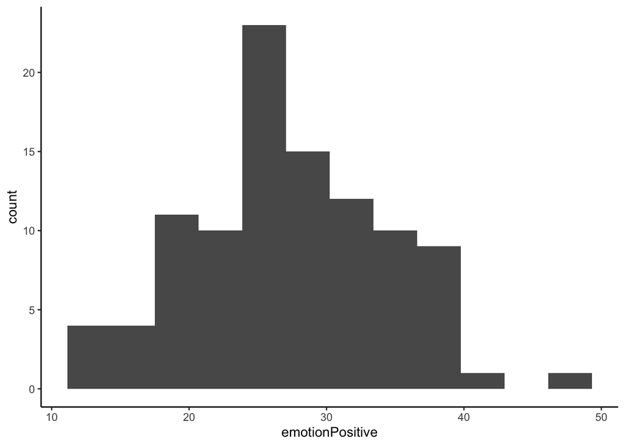

```r
ggplot(df, aes(x = emotionPositive)) +
  geom_histogram(bins = 12) +
  theme_classic()
```

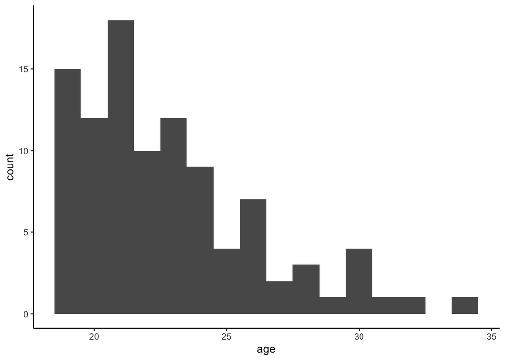

```r
ggplot(df, aes(x = age)) +
  geom_histogram(binwidth = 1) +
  labs() +
  theme_classic()
```

## 1.2 Bar chart (`geom_bar`)

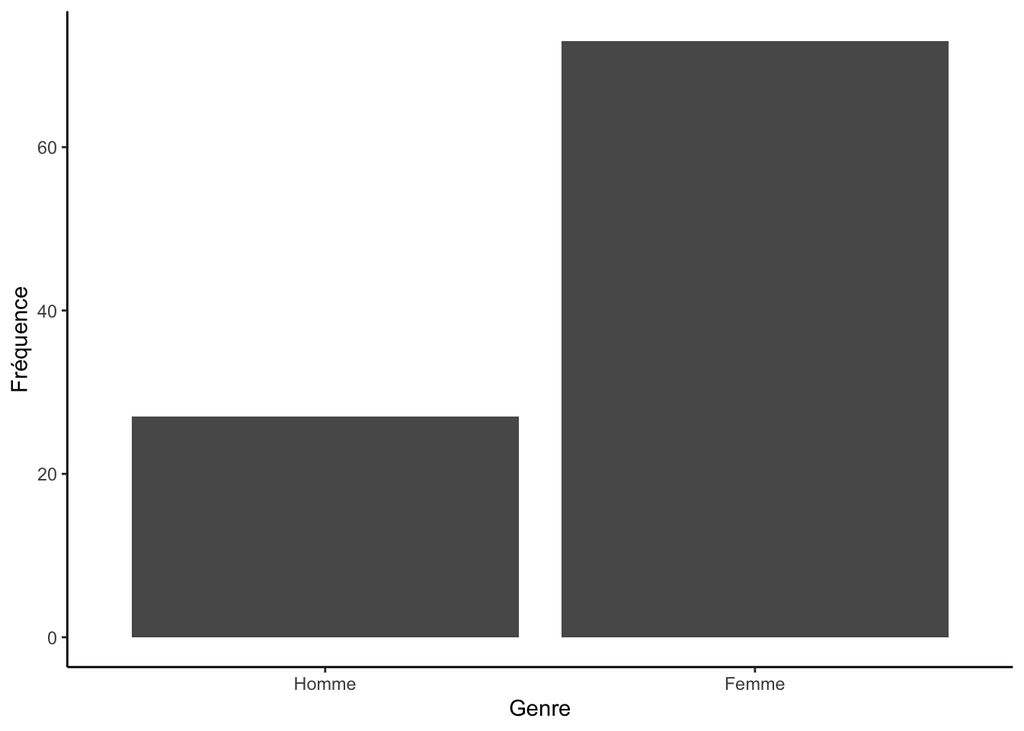

```r
ggplot(df, aes(x = genre)) +
  geom_bar() +
  labs(x = "Genre", y = "Fréquence") +
  theme_classic()
```

## 1.3 Diagramme de dispersion (`geom_point`)

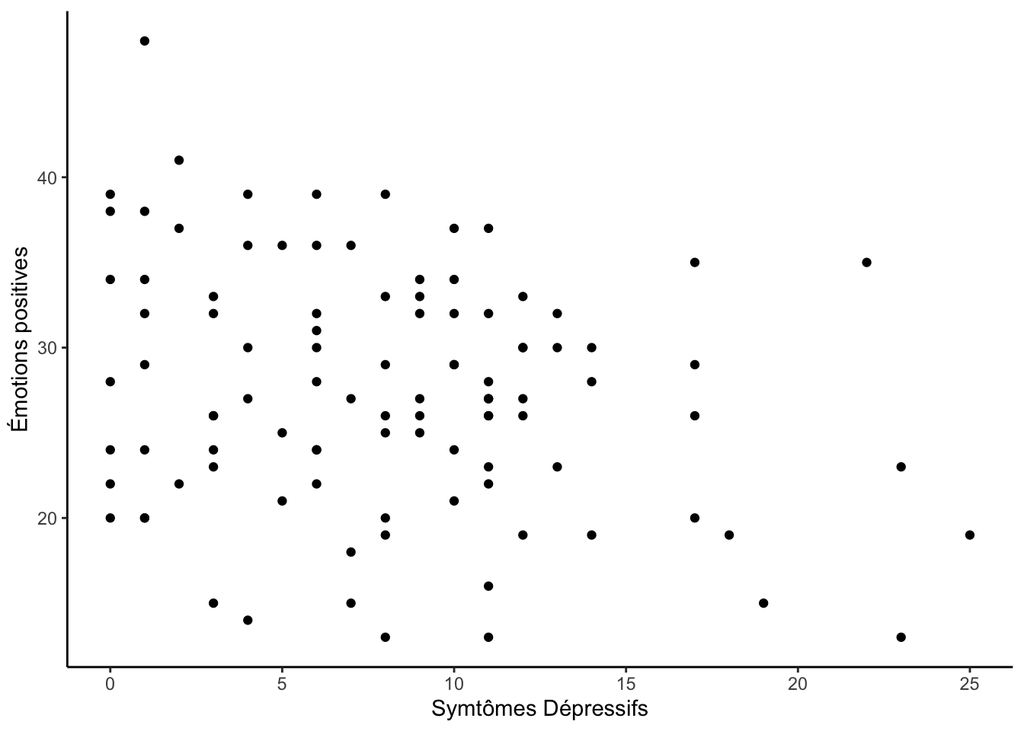

```r
ggplot(df, aes(x = symptomesDepressifs, y = emotionPositive)) +
  geom_point() +
  labs(x = "Symtômes Dépressifs", y = "Émotions positives") +
  theme_classic()
```

## 1.4 Boxplot (`geom_boxplot`)

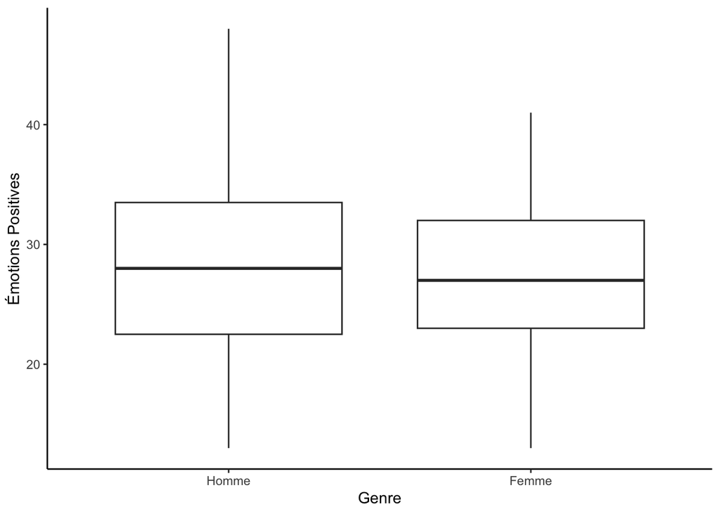

```r
ggplot(df, aes(x = genre, y = emotionPositive)) +
  geom_boxplot() +
  labs(x = "Genre", y = "Émotions Positives") +
  theme_classic()
```

# 2 Ressources supplémentaires

- [Site officiel](https://ggplot2.tidyverse.org/)
- [Cheat sheet `ggplot2`](https://www.maths.usyd.edu.au/u/UG/SM/STAT3022/r/current/Misc/data-visualization-2.1.pdf)